# Lab05

Xiaoya Li

September 28, 2017

## Manipulating and Visualizing Data Frames

### Installing packages

```r
library(dplyr)
```

```r
library(ggplot2)
```

### NBA Players Data

```r
dat <- read.csv('~/UC_Berkeley/Stat133/Lab04/nba2017-players.csv', stringsAsFactors = FALSE)
```

### Filtering, slicing, and selecting

- use slice() to subset the data by selecting the first 5 rows.

```r
slice(dat, 1:5)
```

```
## # A tibble: 5 x 15
##              player  team position height weight   age experience
##               <chr> <chr>    <chr>  <int>  <int> <int>      <int>
## 1        Al Horford   BOS        C     82    245    30          9
## 2      Amir Johnson   BOS       PF     81    240    29         11
## 3     Avery Bradley   BOS       SG     74    180    26          6
## 4 Demetrius Jackson   BOS       PG     73    201    22          0
## 5      Gerald Green   BOS       SF     79    205    31          9
## # ... with 8 more variables: college <chr>, salary <dbl>, games <int>,
## #   minutes <int>, points <int>, points3 <int>, points2 <int>,
## #   points1 <int>
```

- use slice() to subset the data by selecting rows 10, 15, 20, …, 50.

```r
slice(dat, seq(from = 10, to = 50, by = 5))
```

```
## # A tibble: 9 x 15
##             player  team position height weight   age experience
##              <chr> <chr>    <chr>  <int>  <int> <int>      <int>
## 1    Jonas Jerebko   BOS       PF     82    231    29          6
## 2     Tyler Zeller   BOS        C     84    253    27          4
## 3      Edy Tavares   CLE        C     87    260    24          1
## 4       Kevin Love   CLE       PF     82    251    28          8
## 5 Tristan Thompson   CLE        C     81    238    25          5
## 6  DeMarre Carroll   TOR       SF     80    215    30          7
## 7   Lucas Nogueira   TOR        C     84    241    24          2
## 8      Serge Ibaka   TOR       PF     82    235    27          7
## 9    Daniel Ochefu   WAS        C     83    245    23          0
## # ... with 8 more variables: college <chr>, salary <dbl>, games <int>,
## #   minutes <int>, points <int>, points3 <int>, points2 <int>,
## #   points1 <int>
```

- use slice() to subset the data by selecting the last 5 rows.

```r
slice(dat, (nrow(dat) - 4):nrow(dat))
```

```
## # A tibble: 5 x 15
##            player  team position height weight   age experience
##             <chr> <chr>    <chr>  <int>  <int> <int>      <int>
## 1 Marquese Chriss   PHO       PF     82    233    19          0
## 2    Ronnie Price   PHO       PG     74    190    33         11
## 3     T.J. Warren   PHO       SF     80    230    23          2
## 4      Tyler Ulis   PHO       PG     70    150    21          0
## 5  Tyson Chandler   PHO        C     85    240    34         15
## # ... with 8 more variables: college <chr>, salary <dbl>, games <int>,
## #   minutes <int>, points <int>, points3 <int>, points2 <int>,
## #   points1 <int>
```

- use filter() to subset those players with height less than 70 inches tall.

```r
filter(dat, height < 70)
```

```
##          player team position height weight age experience
## 1 Isaiah Thomas  BOS       PG     69    185  27          5
## 2    Kay Felder  CLE       PG     69    176  21          0
##                    college  salary games minutes points points3 points2
## 1 University of Washington 6587132    76    2569   2199     245     437
## 2       Oakland University  543471    42     386    166       7      55
##   points1
## 1     590
## 2      35
```

- use filter() to subset rows of Golden State Warriors (‘GSW’).

```r
gsw <- filter(dat, team == "GSW")
gsw
```

```
##                  player team position height weight age experience
## 1        Andre Iguodala  GSW       SF     78    215  33         12
## 2          Damian Jones  GSW        C     84    245  21          0
## 3            David West  GSW        C     81    250  36         13
## 4        Draymond Green  GSW       PF     79    230  26          4
## 5             Ian Clark  GSW       SG     75    175  25          3
## 6  James Michael McAdoo  GSW       PF     81    230  24          2
## 7          JaVale McGee  GSW        C     84    270  29          8
## 8          Kevin Durant  GSW       SF     81    240  28          9
## 9          Kevon Looney  GSW        C     81    220  20          1
## 10        Klay Thompson  GSW       SG     79    215  26          5
## 11          Matt Barnes  GSW       SF     79    226  36         13
## 12        Patrick McCaw  GSW       SG     79    185  21          0
## 13     Shaun Livingston  GSW       PG     79    192  31         11
## 14        Stephen Curry  GSW       PG     75    190  28          7
```

[output cut: 33 more lines]

- use filter() to subset rows of GSW centers (‘C’).

```r
filter(gsw, position == "C")
```

```
##          player team position height weight age experience
## 1  Damian Jones  GSW        C     84    245  21          0
## 2    David West  GSW        C     81    250  36         13
## 3  JaVale McGee  GSW        C     84    270  29          8
## 4  Kevon Looney  GSW        C     81    220  20          1
## 5 Zaza Pachulia  GSW        C     83    270  32         13
##                                 college  salary games minutes points
## 1                 Vanderbilt University 1171560    10      85     19
## 2                     Xavier University 1551659    68     854    316
## 3            University of Nevada, Reno 1403611    77     739    472
## 4 University of California, Los Angeles 1182840    53     447    135
## 5                                       2898000    70    1268    426
##   points3 points2 points1
## 1       0       8       3
## 2       3     132      43
## 3       0     208      56
## 4       2      54      21
## 5       0     164      98
```

- use filter() and then select(), to subset rows of lakers (‘LAL’), and then display their names.

```r
select(filter(dat, team == "LAL"), player)
```

```
##               player
## 1     Brandon Ingram
## 2       Corey Brewer
## 3   D'Angelo Russell
## 4        David Nwaba
## 5        Ivica Zubac
## 6    Jordan Clarkson
## 7      Julius Randle
## 8    Larry Nance Jr.
## 9          Luol Deng
## 10 Metta World Peace
## 11        Nick Young
## 12       Tarik Black
## 13   Thomas Robinson
## 14    Timofey Mozgov
## 15       Tyler Ennis
```

- use filter() and then select(), to display the name and salary, of GSW point guards

```r
select(filter(dat, team == "GSW" & position == "PG"), player, salary)
```

```
##             player   salary
## 1 Shaun Livingston  5782450
## 2    Stephen Curry 12112359
```

- find how to select the name, age, and team, of players with more than 10 years of experience, making 10 million dollars or less.

```r
select(filter(dat, experience > 10 & salary <= 10000000), player, age, team)
```

```
##               player age team
## 1      Dahntay Jones  36  CLE
## 2     Deron Williams  32  CLE
## 3        James Jones  36  CLE
## 4        Kyle Korver  35  CLE
## 5  Richard Jefferson  36  CLE
## 6      Jose Calderon  35  ATL
## 7     Kris Humphries  31  ATL
## 8      Mike Dunleavy  36  ATL
## 9        Jason Terry  39  MIL
## 10        C.J. Miles  29  IND
## 11     Udonis Haslem  36  MIA
## 12        Beno Udrih  34  DET
## 13        David West  36  GSW
## 14       Matt Barnes  36  GSW
```

[output cut: 18 more lines]

- find how to select the name, team, height, and weight, of rookie players, 20 years old, displaying only the first five occurrences (i.e. rows)

```r
slice(select(filter(dat,experience == 0 & age == 20), player, team, height, weight),1:5)
```

```
## # A tibble: 5 x 4
##              player  team height weight
##               <chr> <chr>  <int>  <int>
## 1      Jaylen Brown   BOS     79    225
## 2    Henry Ellenson   DET     83    245
## 3 Stephen Zimmerman   ORL     84    240
## 4   Dejounte Murray   SAS     77    170
## 5    Chinanu Onuaku   HOU     82    245
```

### Adding new variables: mutate()

```r
# creating a small data frame step by step
gsw <- filter(dat, team == 'GSW')
gsw <- select(gsw, player, height, weight)
gsw <- slice(gsw, c(4, 8, 10, 14, 15))
gsw
```

```
## # A tibble: 5 x 3
##           player height weight
##            <chr>  <int>  <int>
## 1 Draymond Green     79    230
## 2   Kevin Durant     81    240
## 3  Klay Thompson     79    215
## 4  Stephen Curry     75    190
## 5  Zaza Pachulia     83    270
```

### Reordering rows: arrange()

- using the data frame gsw, add a new variable product with the product of height and weight.

```r
gsw2 <- mutate(gsw, product = height * weight)
gsw2
```

```
## # A tibble: 5 x 4
##           player height weight product
##            <chr>  <int>  <int>   <int>
## 1 Draymond Green     79    230   18170
## 2   Kevin Durant     81    240   19440
## 3  Klay Thompson     79    215   16985
## 4  Stephen Curry     75    190   14250
## 5  Zaza Pachulia     83    270   22410
```

- create a new data frame gsw3, by adding columns log_height and log_weight with the log transformations of height and weight.

```r
gsw3 <- mutate(gsw, log_height = log(height), log_weight = log(weight))
gsw3
```

```
## # A tibble: 5 x 5
##           player height weight log_height log_weight
##            <chr>  <int>  <int>      <dbl>      <dbl>
## 1 Draymond Green     79    230   4.369448   5.438079
## 2   Kevin Durant     81    240   4.394449   5.480639
## 3  Klay Thompson     79    215   4.369448   5.370638
## 4  Stephen Curry     75    190   4.317488   5.247024
## 5  Zaza Pachulia     83    270   4.418841   5.598422
```

- use the original data frame to filter() and arrange() those players with height less than 71 inches tall, in increasing order.

```r
arrange(filter(dat, height < 71), height)
```

```
##          player team position height weight age experience
## 1 Isaiah Thomas  BOS       PG     69    185  27          5
## 2    Kay Felder  CLE       PG     69    176  21          0
## 3    Tyler Ulis  PHO       PG     70    150  21          0
##                    college  salary games minutes points points3 points2
## 1 University of Washington 6587132    76    2569   2199     245     437
## 2       Oakland University  543471    42     386    166       7      55
## 3   University of Kentucky  918369    61    1123    444      21     163
##   points1
## 1     590
## 2      35
## 3      55
```

- display the name, team, and salary, of the top-5 highest paid players

```r
slice(select(arrange(dat, desc(salary)), player, team, salary), 1:5)
```

```
## # A tibble: 5 x 3
##          player  team   salary
##           <chr> <chr>    <dbl>
## 1  LeBron James   CLE 30963450
## 2    Al Horford   BOS 26540100
## 3 DeMar DeRozan   TOR 26540100
## 4  Kevin Durant   GSW 26540100
## 5  James Harden   HOU 26540100
```

- display the name, team, and points3, of the top 10 three-point players

```r
slice(select(arrange(dat, desc(points3)), player, team, points3), 1: 10)
```

```
## # A tibble: 10 x 3
##            player  team points3
##             <chr> <chr>   <int>
##  1  Stephen Curry   GSW     324
##  2  Klay Thompson   GSW     268
##  3   James Harden   HOU     262
##  4    Eric Gordon   HOU     246
##  5  Isaiah Thomas   BOS     245
##  6   Kemba Walker   CHO     240
##  7   Bradley Beal   WAS     223
##  8 Damian Lillard   POR     214
##  9  Ryan Anderson   HOU     204
## 10    J.J. Redick   LAC     201
```

```r
gsw_mpg <- mutate(filter(dat, team == "GSW"), min_per_game = minutes / games )
gsw_mpg <- select(gsw_mpg, player, experience, min_per_game)
arrange(gsw_mpg, min_per_game)
```

```
##                  player experience min_per_game
## 1          Kevon Looney          1     8.433962
## 2          Damian Jones          0     8.500000
## 3  James Michael McAdoo          2     8.788462
## 4          JaVale McGee          8     9.597403
## 5            David West         13    12.558824
## 6             Ian Clark          3    14.766234
## 7         Patrick McCaw          0    15.126761
## 8      Shaun Livingston         11    17.697368
## 9         Zaza Pachulia         13    18.114286
## 10          Matt Barnes         13    20.500000
## 11       Andre Iguodala         12    26.289474
## 12       Draymond Green          4    32.513158
## 13         Kevin Durant          9    33.387097
## 14        Stephen Curry          7    33.392405
## 15        Klay Thompson          5    33.961538
```

### Summarizing values with summarise()

### Grouped operations

- use summarise() to get the largest height value.

```r
summarise(dat, max(height))
```

```
##   max(height)
## 1          87
```

- use summarise() to get the standard deviation of points3.

```r
summarise(dat, sd(points3))
```

```
##   sd(points3)
## 1     55.9721
```

- use summarise() and group_by() to display the median of three-points, by team.

```r
summarise(
  group_by(dat,team),
  median(points3)
)
```

```
## # A tibble: 30 x 2
##     team `median(points3)`
##    <chr>             <dbl>
##  1   ATL              32.5
##  2   BOS              46.0
##  3   BRK              44.0
##  4   CHI              32.0
##  5   CHO              17.0
##  6   CLE              62.0
##  7   DAL              53.0
##  8   DEN              53.0
##  9   DET              28.0
## 10   GSW              18.0
## # ... with 20 more rows
```

- display the average triple points by team, in ascending order, of the bottom-5 teams (worst 3pointer teams)

```r
slice(
  arrange(
   summarise(
     group_by(dat, team),
      average_points3 = mean(points3)
   ),
   average_points3
  ),
  1:5
)
```

```
## # A tibble: 5 x 2
##    team average_points3
##   <chr>           <dbl>
## 1   NOP        36.64286
## 2   SAC        37.20000
## 3   PHO        37.60000
## 4   CHI        37.66667
## 5   LAL        39.46667
```

- obtain the mean and standard deviation of age, for Power Forwards, with 5 and 10 years (including) years of experience.

```r
summarise(
  filter(dat, experience >= 5 & experience <= 10 & position == "PF"),
  mean(age),
  sd(age)
)
```

```
##   mean(age)  sd(age)
## 1  28.12903 1.802627
```

## First contact with ggplot()

### Scatterplots

- Use the data frame gsw to make a scatterplot of height and weight

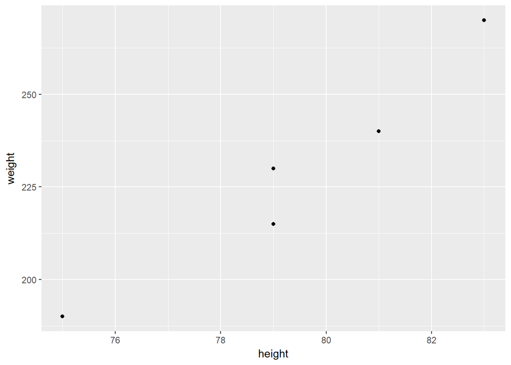

```r
ggplot(gsw) +
  geom_point(aes(x = height, y = weight))
```

- Find out how to make another scatterplot of height and weight, using geom_text() to display the names of the players

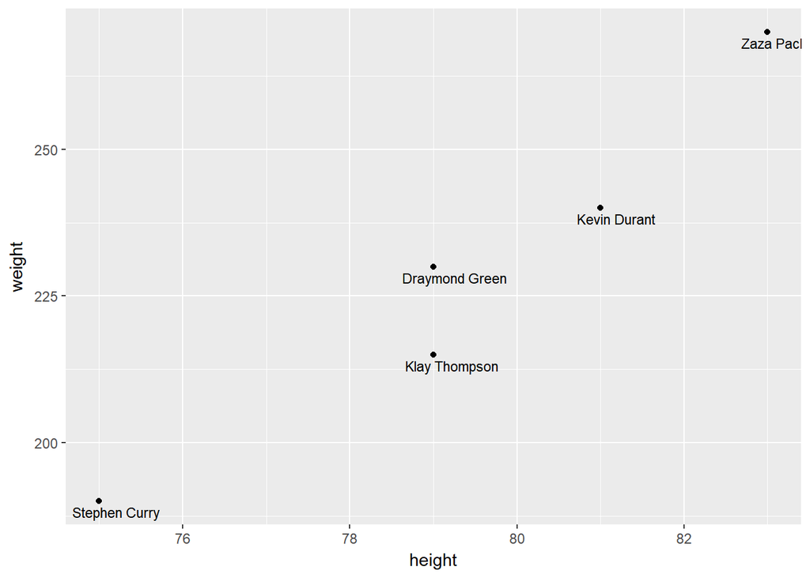

```r
ggplot(gsw, aes(x = height, y = weight, label = player) ) +
  geom_point() +
  geom_text(size = 3, vjust = 1.5, hjust = 0.3)
```

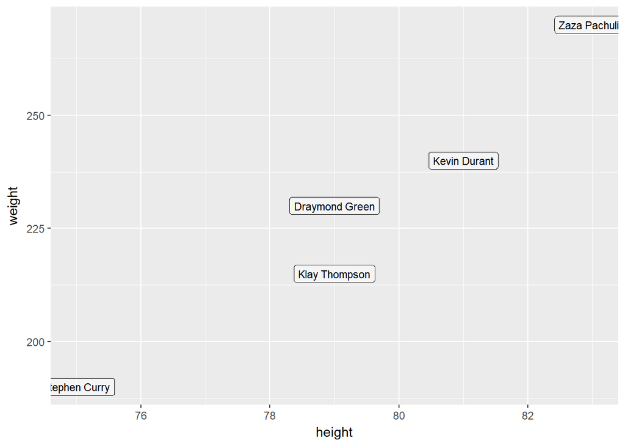

```r
ggplot(gsw, aes(x = height, y = weight, label = player)) +
  geom_label(size = 3, alpha = 0.5)
```

- Get a density plot of salary (for all NBA players)

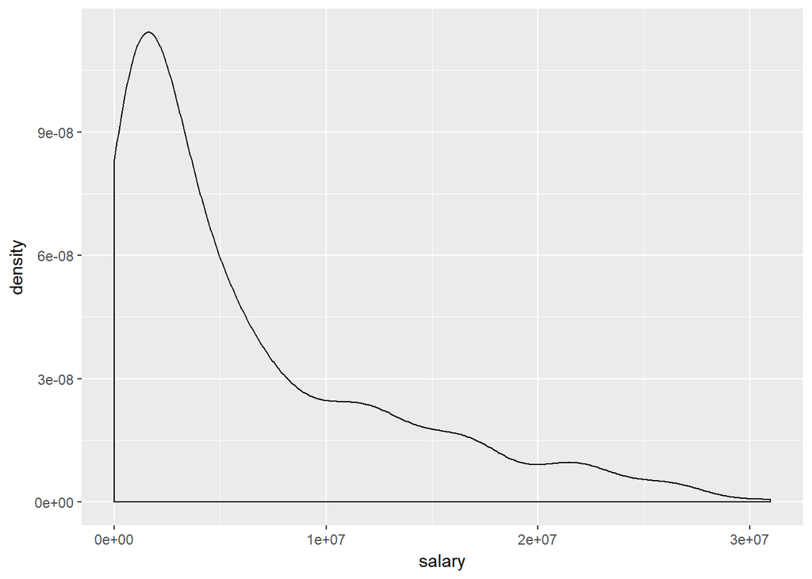

```r
ggplot(dat, aes(x = salary)) +
  geom_density()
```

- Get a histogram of points2 with binwidth of 50 (for all NBA players)

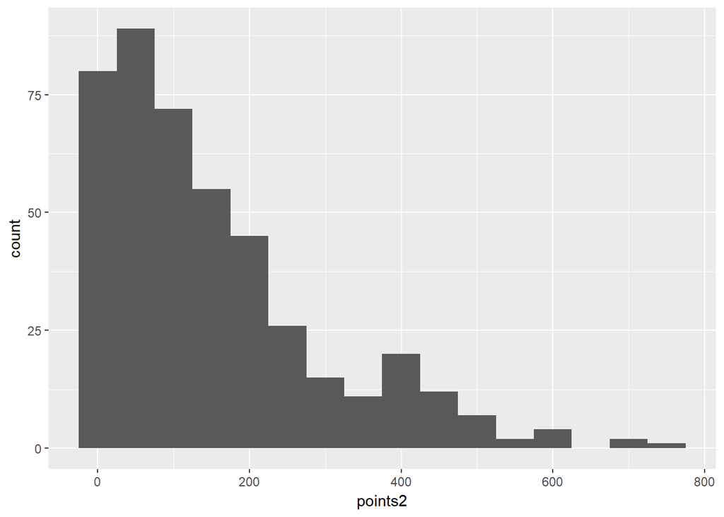

```r
ggplot(dat, aes(x = points2)) +
  geom_histogram(binwidth = 50)
```

- Get a barchart of the position frequencies (for all NBA players)

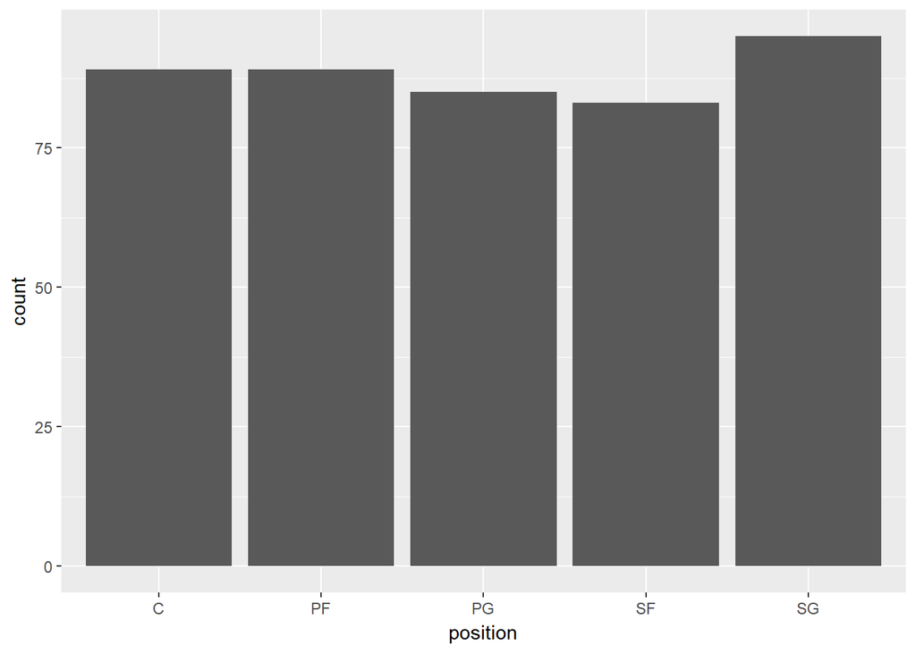

```r
ggplot(dat, aes(position)) +
  geom_bar()
```

- Make a scatterplot of experience and salary of all centers, and use geom_smooth() to add a regression line

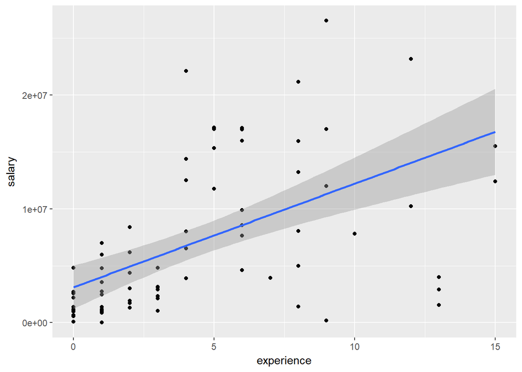

```r
ggplot(filter(dat, position == "C"), aes(x = experience, y = salary)) +
  geom_point() +
  geom_smooth(method = lm)
```

- Repeat the same scatterplot of experience and salary of all centers, but now use geom_smooth() to add a loess line

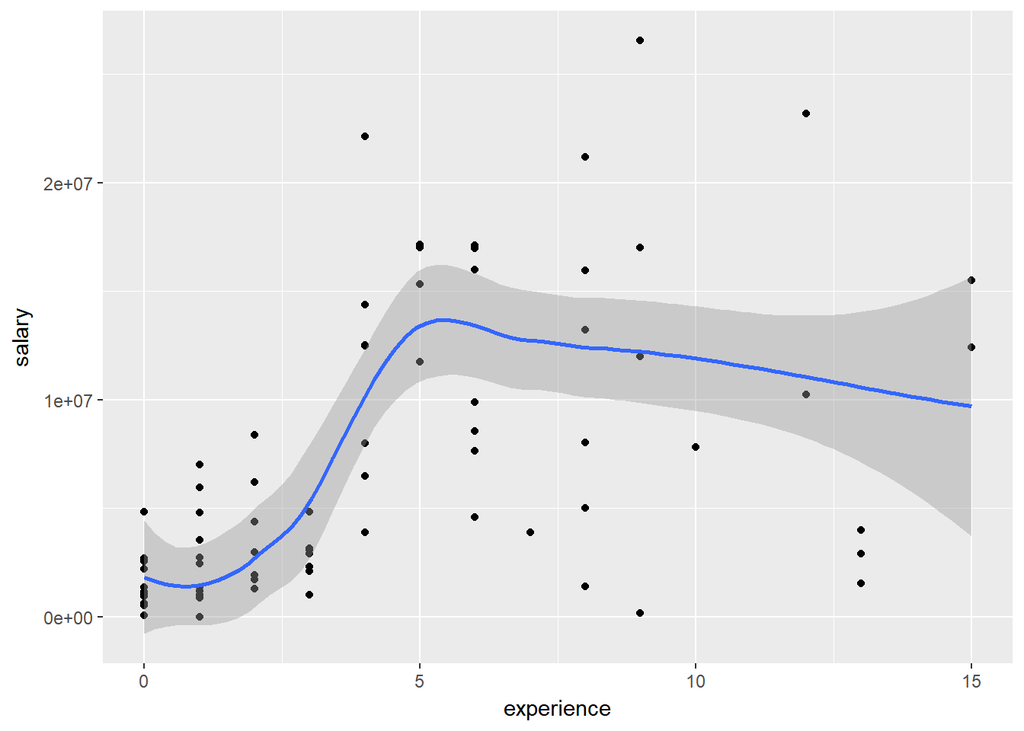

```r
ggplot(filter(dat, position == "C"), aes(x = experience, y = salary)) +
  geom_point() +
  geom_smooth()
```

### Faceting

- Make scatterplots of experience and salary faceting by position

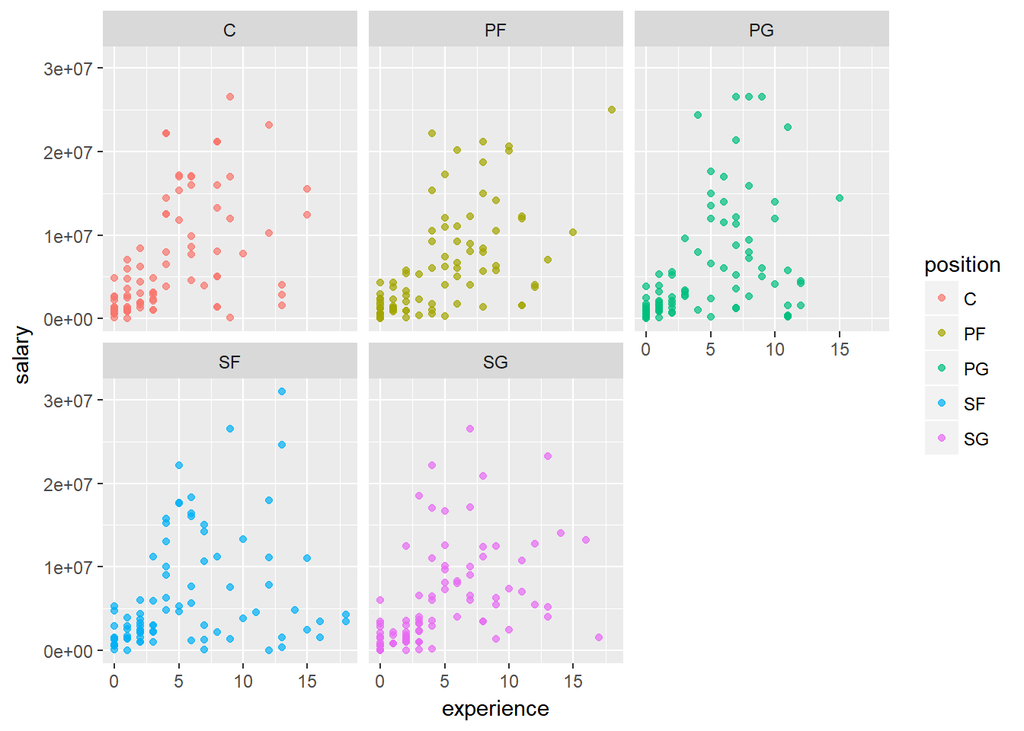

```r
ggplot(dat, aes(x = experience, y = salary)) +
  geom_point(aes(color = position), alpha = 0.7) +
  facet_wrap( ~ position)
```

- Make scatterplots of experience and salary faceting by team

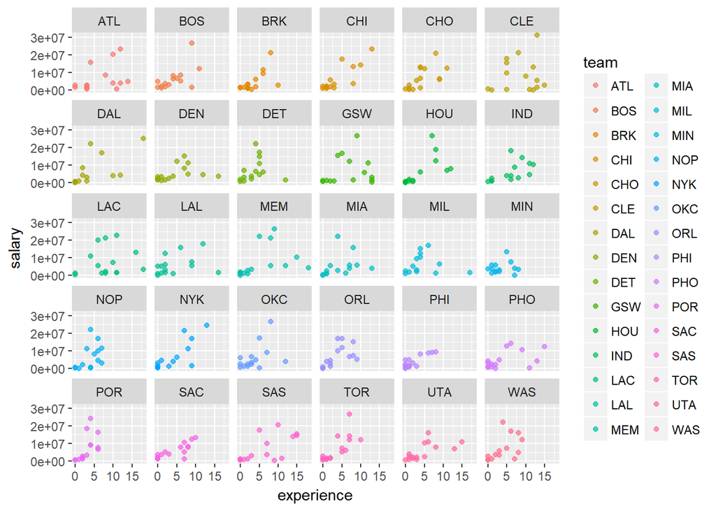

```r
ggplot(dat, aes(x = experience, y = salary)) +
  geom_point(aes(color = team), alpha = 0.7) +
  facet_wrap( ~ team)
```

- Make density plots of age faceting by team

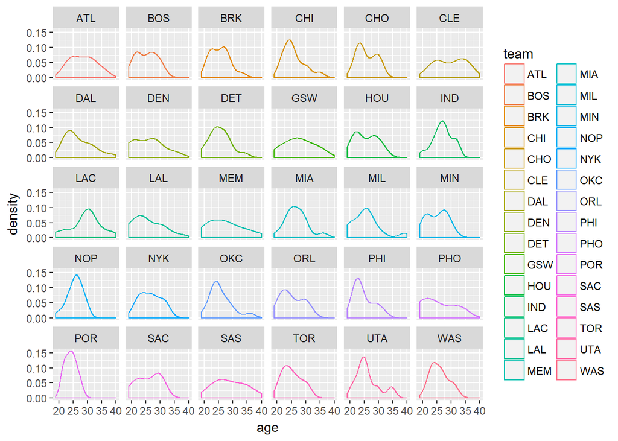

```r
ggplot(dat, aes(x = age)) +
  geom_density(aes(color = team)) +
  facet_wrap(~ team)
```

- Make scatterplots of height and weight faceting by position

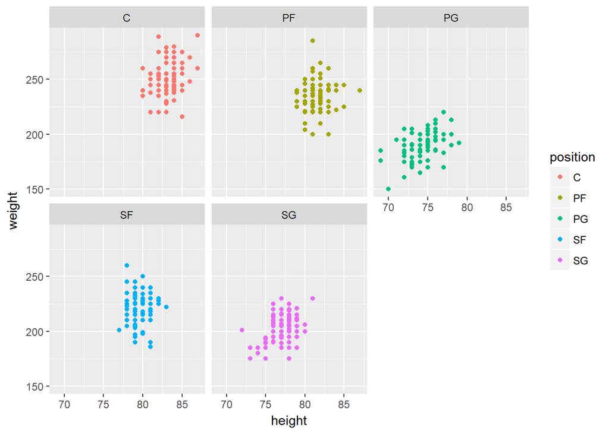

```r
ggplot(dat, aes(x = height, y = weight)) +
  geom_point(aes(color = position)) +
  facet_wrap(~ position)
```

- Make scatterplots of height and weight, with a 2-dimensional density, geom_density2d(), faceting by position

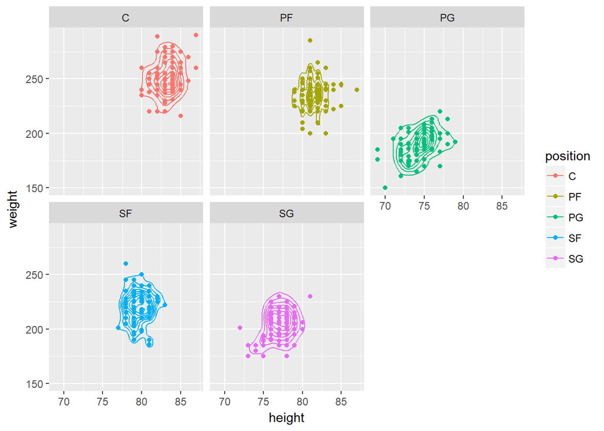

```r
ggplot(dat, aes(x = height, y = weight)) +
  geom_point(aes(color = position)) +
  geom_density2d(aes(color = position)) +
  facet_wrap(~ position)
```